# ML2 Team 1 Presentation 2

### GBM

```r
library(caret)
Loading required package: lattice
Loading required package: ggplot2
```

Fit GBM

```r
GBM <- train(isFraud~.,data = Train,method = "gbm",
             preProcess = c("scale", "center"),trControl = trainControl(method = "cv",
                                                                        number = 3, verboseIter = TRUE),verbose = 0)
+ Fold1: shrinkage=0.1, interaction.depth=1, n.minobsinnode=10, n.trees=150
- Fold1: shrinkage=0.1, interaction.depth=1, n.minobsinnode=10, n.trees=150
+ Fold1: shrinkage=0.1, interaction.depth=2, n.minobsinnode=10, n.trees=150
- Fold1: shrinkage=0.1, interaction.depth=2, n.minobsinnode=10, n.trees=150
+ Fold1: shrinkage=0.1, interaction.depth=3, n.minobsinnode=10, n.trees=150
- Fold1: shrinkage=0.1, interaction.depth=3, n.minobsinnode=10, n.trees=150
+ Fold2: shrinkage=0.1, interaction.depth=1, n.minobsinnode=10, n.trees=150
- Fold2: shrinkage=0.1, interaction.depth=1, n.minobsinnode=10, n.trees=150
+ Fold2: shrinkage=0.1, interaction.depth=2, n.minobsinnode=10, n.trees=150
- Fold2: shrinkage=0.1, interaction.depth=2, n.minobsinnode=10, n.trees=150
+ Fold2: shrinkage=0.1, interaction.depth=3, n.minobsinnode=10, n.trees=150
- Fold2: shrinkage=0.1, interaction.depth=3, n.minobsinnode=10, n.trees=150
+ Fold3: shrinkage=0.1, interaction.depth=1, n.minobsinnode=10, n.trees=150
- Fold3: shrinkage=0.1, interaction.depth=1, n.minobsinnode=10, n.trees=150
+ Fold3: shrinkage=0.1, interaction.depth=2, n.minobsinnode=10, n.trees=150
- Fold3: shrinkage=0.1, interaction.depth=2, n.minobsinnode=10, n.trees=150
+ Fold3: shrinkage=0.1, interaction.depth=3, n.minobsinnode=10, n.trees=150
- Fold3: shrinkage=0.1, interaction.depth=3, n.minobsinnode=10, n.trees=150
Aggregating results
Selecting tuning parameters
Fitting n.trees = 150, interaction.depth = 3, shrinkage = 0.1, n.minobsinnode = 10 on full training set

GBM
Stochastic Gradient Boosting

590539 samples
    12 predictor
     2 classes: '0', '1'

Pre-processing: scaled (18), centered (18)
Resampling: Cross-Validated (3 fold)
Summary of sample sizes: 393693, 393693, 393692
Resampling results across tuning parameters:

  interaction.depth  n.trees  Accuracy   Kappa
  1                   50      0.9648660  9.298167e-05
  1                  100      0.9648829  1.201305e-03
  1                  150      0.9648982  2.126108e-03
  2                   50      0.9648711  3.719434e-04
  2                  100      0.9649049  3.032732e-03
  2                  150      0.9649371  5.857689e-03
  3                   50      0.9648762  1.545281e-03
  3                  100      0.9649659  8.132696e-03
  3                  150      0.9650082  1.263398e-02

Tuning parameter 'shrinkage' was held constant at a value of 0.1
Tuning
 parameter 'n.minobsinnode' was held constant at a value of 10
Accuracy was used to select the optimal model using the largest value.
The final values used for the model were n.trees = 150, interaction.depth =
 3, shrinkage = 0.1 and n.minobsinnode = 10.
```

Find GBM Classes

```r
preds<-predict(GBM,newdata = Test)
table(preds,Test$isFraud)

preds      0      1
    0 114034   4047
    1     10     17
```

Get GBM Probabilities

```r
predsVal<-predict(GBM,Test,type='prob')
```

Take only positive value class values

```r
Only<-predsVal[,2]
```

Plot AUC

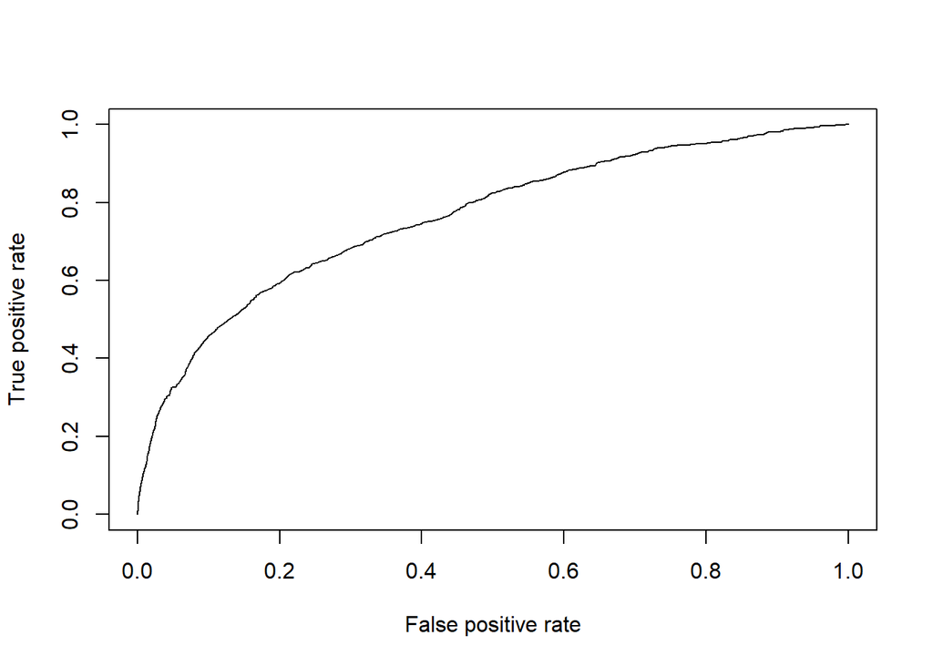

```r
library(ROCR)
GBM_AUCThing <- prediction(Only,Test$isFraud, label.ordering = c(0,1))
GBM_Chart <- performance(GBM_AUCThing,"tpr", "fpr")
plot(GBM_Chart)
```

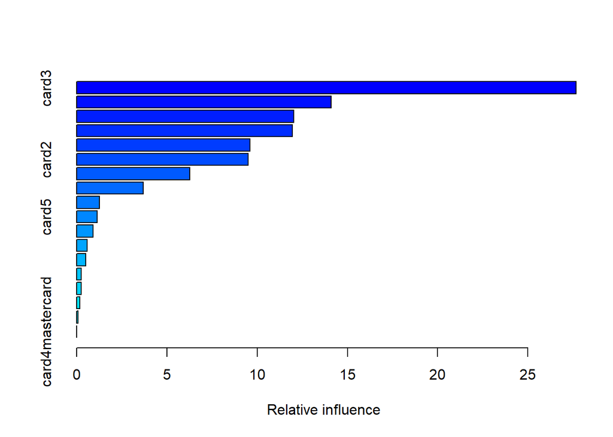

```
                                        var    rel.inf
card3                                 card3 27.6659557
TransactionAmt               TransactionAmt 14.1028723
card6debit                       card6debit 12.0179188
addr2                                 addr2 11.9601203
card1                                 card1  9.6070327
card2                                 card2  9.5008310
ProductCDH                       ProductCDH  6.2714601
ProductCDW                       ProductCDW  3.6925918
addr1                                 addr1  1.2700904
card5                                 card5  1.1424911
ProductCDS                       ProductCDS  0.9206812
card4visa                         card4visa  0.5834824
card4discover                 card4discover  0.5169400
MatchedTRUE                     MatchedTRUE  0.2585954
card4american express card4american express  0.2493072
EmailsMatchTRUE             EmailsMatchTRUE  0.1705982
ProductCDR                       ProductCDR  0.0690314
card4mastercard             card4mastercard  0.0000000
```

```r
Gbm_Final<-GBM$finalModel
summary(Gbm_Final)
```

Get AUC value

```r
auc_ROCR <- performance(GBM_AUCThing, measure = "auc")
auc_ROCR <- auc_ROCR@y.values[[1]]
auc_ROCR # [1] 0.7619435
[1] 0.762326
```

### Conclusion

Plots for all models

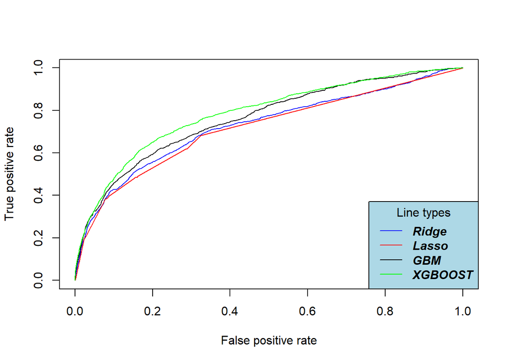

```r
plot(Ridge_Chart, col = "blue")
plot(Lasso_Chart, add = TRUE, col = "red")
plot(GBM_Chart, add = TRUE, col = "black")
plot(XGBOOST_Chart, add = TRUE, col = "green")
legend("bottomright", legend=c("Ridge", "Lasso ","GBM","XGBOOST"),
       col=c( "blue","red","black","green","orange"), lty=1,
       title="Line types", text.font=4, bg='lightblue')
```

**Conclusions**

XGBoost provided the best model performance but still fell far short of the top models in the competition.

Our Model may have performed better on the Test data as it seemed other groups training splits also were not as good as their ultimate test score

Model Performance is harder to measure and improve with unbalanced data sets.

Data cleanup and feature engineering are important

Know your data, especially if you do not use a Neural Network!

Sometimes the model with the best testing accuracy isn’t the most defendable or understandable one.